# Starbucks más Frecuentados

Martín Salinas Antón y Belén Vivas García

12 Mayo de 2023

# Inicialización

El siguiente código ha sido probado con R version 4.3.0 (2023-04-21) y RStudio 1.2.240

Primeramente, es necesario cargar todas las bibliotecas que se van a emplear durante el proyecto.

```r
library(tidyverse)
library(cowplot)
library(hexbin)
library(lubridate)
library(scales)

#theme_set(theme_cowplot(font_size=12)) # reduce default font size
```

Recordar que es preciso instalar previamente aquellas bibliotecas que no estuvieran disponibles. Por ejemplo:

```
install.packages("tidyverse")
```

Cargamos también funciones que nos son útiles en la última parte de la práctica. La función permite `gcd_slc` calcula la distancia geodésica entre dos puntos definidos en coordenadas cartesianas. Precisa de la función `deg2rad` para convertir dichas coordenadas de grados a radianes.

```r
# source: https://www.r-bloggers.com/great-circle-distance-calculations-in-r/
# Convert degrees to radians
deg2rad <- function(deg) {
    return(deg*pi/180)
}

# Calculates the great-circle distance (gdc), also called geodesic distance,
# between two points specified by radian latitude/longitude using the Spherical
# Law of Cosines (slc) The Spherical Law of Cosines performs well as long as the
# distance is not to small (some sources claim it’s accuracy deteriorates at
# about the 1 metre scale).
# Return distance in Km
gcd_slc <- function(long1, lat1, long2, lat2) {
    # Convert degrees to radians
    long1 <- deg2rad(long1)
    lat1 <- deg2rad(lat1)
    long2 <- deg2rad(long2)
    lat2 <- deg2rad(lat2)

    R <- 6371 # Earth mean radius [km]
    d <- acos(sin(lat1)*sin(lat2) + cos(lat1)*cos(lat2) * cos(long2-long1)) * R
    return(d) # Distance in km
}
```

# Dataset taxis de Nueva York

El conjunto de datos que vamos a utilizar contiene los viajes realizados el día 14 de enero de 2013, y se puede descargar desde:

https://www.dropbox.com/s/nmtodtuvpb8f87d/trip_data_2013-01-14.csv?dl=1

```r
taxis_df <- read_csv("data/trip_data_2013-01-14.csv")
```

```r
# Incluir las coordenadas correspondientes, y ejecutar el trozo de código
nw <- list(lat = 40.917577, lon = -74.259090)
se <- list(lat = 40.477399, lon = -73.700272)
```

Una vez definido el *bounding box* se sustituye por `NA` cualquier coordenada que se encuentre fuera.

```r
# set coordinates outside of NYC bounding box to NA
taxis_df <- taxis_df %>%
        mutate(pickup_longitude = replace(pickup_longitude,
                                           which(pickup_longitude < nw$lon
                                                 | pickup_longitude > se$lon),
                                           NA)) %>%
        mutate(pickup_latitude = replace(pickup_latitude,
                                           which(pickup_latitude < se$lat
                                                 | pickup_latitude > nw$lat),
                                           NA)) %>%
        mutate(dropoff_longitude = replace(dropoff_longitude,
                                           which(dropoff_longitude < nw$lon
                                                 | dropoff_longitude > se$lon),
                                           NA)) %>%
        mutate(dropoff_latitude = replace(dropoff_latitude,
                                           which(dropoff_latitude < se$lat
                                                 | dropoff_latitude > nw$lat),
                                           NA))
```

```r
taxis_df <- taxis_df %>%
  # Trip distance greater than 0
  mutate(trip_distance = replace(trip_distance,
                                 which(trip_distance <= 0),
                                 NA)) %>%
  # Trip time in secs greater than 0
  mutate(trip_time_in_secs = replace(trip_time_in_secs,
                                     which(trip_time_in_secs <= 0),
                                     NA)) %>%
  # Rate code greater than 0
  mutate(rate_code = replace(rate_code,
                             which(rate_code <= 0),
                             NA)) %>%
  # Passenger count between 1 and 6
  mutate(passenger_count = replace(passenger_count,
                                   which(passenger_count < 1
                                         | passenger_count > 6),
                                   NA))
```

Eliminamos el atributo *store_and_fwd_flag* ya que tiene un número elevado de `NA`, y además no sabemos interpretar.

```r
taxis_df <- taxis_df %>% select(-store_and_fwd_flag)
table(complete.cases(taxis_df))
```

```
 FALSE   TRUE
 11210 432174
```

# Parte de desarrollo propio

La última parte de la práctica consiste en realizar un desarrollo propio en el que se van a combinar un nuevo conjunto de datos con los ya existente.

Desde esta URL:

https://www.dropbox.com/s/lowbxfx2uohlxy3/All_Starbucks_Locations_in_the_US_2013.csv?dl=1

te puedes bajar todas las ubicaciones que tenían los Starbucks de Estados Unidos en el año 2013. Se pide estimar los *cinco Starbucks* que tienen más clientes a partir de la actividad de los taxis.

```r
starbucks_df <- read_csv("data/All_Starbucks_Locations_in_the_US_2013.csv")
```

Primero nos quedamos con los Starbucks que estén únicamente dentro de los límites de NYC.

```r
# Starbucks in NYC
starbucks_nyc <- starbucks_df %>%
                    filter(nw$lon < Longitude & Longitude < se$lon ) %>%
                    filter(se$lat < Latitude & Latitude < nw$lat)
```

Podríamos haber filtrado directamente por el campo State y quedarnos sólo con los de NY, pero tendríamos que acotar aún más, ya que no queremos todos los del estado de Nueva York, sino los de la ciudad de Nueva York.

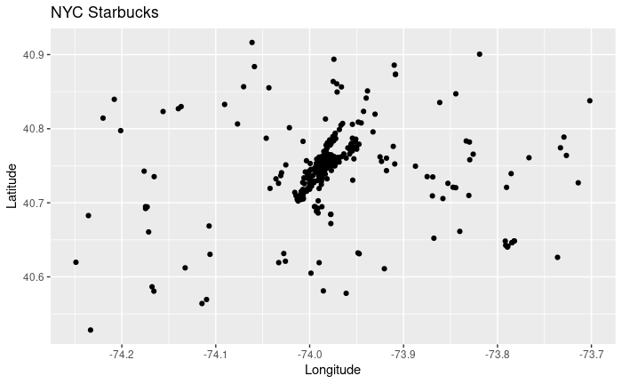

```r
ggplot(starbucks_nyc, aes(x = Longitude, y = Latitude)) + geom_point() +
  ggtitle("NYC Starbucks") +
  xlab("Longitude") +
  ylab("Latitude")
```

Vemos que la mayoría de Starbucks están en la zona de Manhattan.

```r
# Drop NA values from coordinates
taxis_df <- na.omit(taxis_df, cols=c('pickup_longitude', 'pickup_latitude', 'dropoff_longitude', 'dropoff_latitude'))

# Calculates distance between taxis and starbucks coordinates
starbucks_taxi_dist <- function(taxi_lon, taxi_lat, starbucks_lon, starbucks_lat) {
  gcd_slc(taxi_lon, taxi_lat, starbucks_lon, starbucks_lat)
}
```

Añadimos una columna en el dataframe de los taxis con el ID del Starbucks más cercano al punto de bajada. Esto lo hacemos calculando las distancias mínimas de los puntos de bajada con los Starbucks más cercanos, utilizando la función `starbucks_taxi_dist` definida anteriormente, la cual realiza el cálculo llamando a `gcd_slc`.

```r
# New column with the closest starbucks to the dropoff point
taxis_df$closest_starbucks <- apply(taxis_df, 1, function(x) {
  starbucks_nyc[['Facility ID']][which.min(starbucks_taxi_dist(as.numeric(x[['dropoff_longitude']]), as.numeric(x[['dropoff_latitude']]), as.numeric(starbucks_nyc$Longitude), as.numeric(starbucks_nyc$Latitude)))]
})
```

Calculamos la frecuencia con la que aparece cada Starbucks en la nueva columna, y tomaremos los 5 más frecuentes como solución al problema.

```r
# Frequency dataframe
starbucks_freq <- as.data.frame(table(taxis_df$closest_starbucks))
starbucks_freq <- starbucks_freq[order(starbucks_freq$Freq, decreasing = TRUE), ]

# Take 5 first Starbucks
starbucks_freq_5 <- starbucks_freq[1:5, ]
# Rename variable
starbucks_freq_5 <- starbucks_freq_5 %>%
  rename(ID = Var1)

# Retrieve latitude and longitude from those Starbucks
top_5_starbucks <- starbucks_nyc %>%
  filter(`Facility ID` %in% starbucks_freq_5$ID) %>%
  select(`Facility ID`, Name, Latitude, Longitude)
```

Finalmente, graficamos los puntos donde se encuentran estos Starbucks.

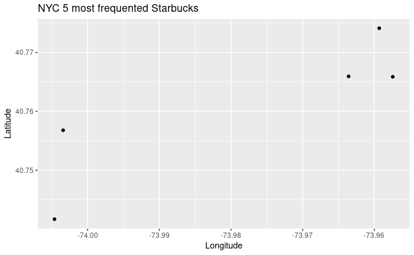

```r
ggplot(top_5_starbucks, aes(x = Longitude, y = Latitude)) + geom_point() +
  ggtitle("NYC 5 most frequented Starbucks") +
  xlab("Longitude") +
  ylab("Latitude")
```

Y sus nombres:

```r
top_5_starbucks$Name
```

```
[1] "Lexington & 78th"                 "69th & First"                     "Third @ 66th"
[4] "15th & Ninth"                     "Javits Convention Ctr Taxi North"
```

Como podemos ver, se encuentran en un rango de longitud y latitud dentro de los límites de Manhattan. Tiene sentido, ya que Manhattan es la zona más transitada y donde más taxis paran y, por tanto, donde más gente pasará por un Starbucks al bajarse del taxi.